# Assignment 1

## Question 1

### Case 0: Result without Changes

```r
result <- dtree(yl = "kcl_input_complex")
summary(result, input = TRUE, output = FALSE)
```

```
Decision tree input:
name: KCL
variables:
    prof: 10*3000
    q: 0.2
type: decision
Truck:
    type: chance
    High cost:
        p: 0.5
        payoff: prof - 4*3000
    Medium cost:
        p: 0.25
        payoff: prof - 3*3000
    Low cost:
        p: 0.25
        payoff: prof - 2*3000
Cancel immediately:
    payoff: 1/2*(-24000-45000)
Wait:
    type: chance
    Storm misses:
        p: 0.5
        payoff: prof
    Storm hits:
        p: 0.5
        type: chance
        Logan open:
            p: 1-q
            payoff: prof
        Logan closes:
            p: q
            type: decision
            MAF:
                type: chance
                High air cost:
                    p: 1/3
                    payoff: prof - 19*3000
                Low air cost:
                    p: 2/3
                    payoff: prof - 13*3000
            Cancel at 5:
                payoff: 1/2*(-24750-45750)
```

```r
plot(result, final = TRUE) %>% render()
```

[interactive chart not shown]

#### Conclusion

Without Making any changes, our best choice is to wait.

### Case 1: Result When the Probability that the airport stays open drops to % 60

```r
result <- dtree(yl = "kcl_60pcnt_input_complex")
summary(result, input = TRUE, output = FALSE)
```

```
Decision tree input:
name: KCL
variables:
    prof: 10*3000
    q: 0.4
type: decision
Truck:
    type: chance
    High cost:
        p: 0.5
        payoff: prof - 4*3000
    Medium cost:
        p: 0.25
        payoff: prof - 3*3000
    Low cost:
        p: 0.25
        payoff: prof - 2*3000
Cancel immediately:
    payoff: 1/2*(-24000-45000)
Wait:
    type: chance
    Storm misses:
        p: 0.5
        payoff: prof
    Storm hits:
        p: 0.5
        type: chance
        Logan open:
            p: 1-q
            payoff: prof
        Logan closes:
            p: q
            type: decision
            MAF:
                type: chance
                High air cost:
                    p: 1/3
                    payoff: prof - 19*3000
                Low air cost:
                    p: 2/3
                    payoff: prof - 13*3000
            Cancel at 5:
                payoff: 1/2*(-24750-45750)
```

```r
plot(result, final = TRUE) %>% render()
```

[interactive chart not shown]

#### Conclusion

When the probability that Logan Airport remains open drops to 60%, our decision does not change.

### Cast 2: Result When the Probability that the airport stays open drops to % 50

```r
result <- dtree(yl = "kcl_50pcnt_input_complex")
summary(result, input = TRUE, output = FALSE)
```

```
Decision tree input:
name: KCL
variables:
    prof: 10*3000
    q: 0.5
type: decision
Truck:
    type: chance
    High cost:
        p: 0.5
        payoff: prof - 4*3000
    Medium cost:
        p: 0.25
        payoff: prof - 3*3000
    Low cost:
        p: 0.25
        payoff: prof - 2*3000
Cancel immediately:
    payoff: 1/2*(-24000-45000)
Wait:
    type: chance
    Storm misses:
        p: 0.5
        payoff: prof
    Storm hits:
        p: 0.5
        type: chance
        Logan open:
            p: 1-q
            payoff: prof
        Logan closes:
            p: q
            type: decision
            MAF:
                type: chance
                High air cost:
                    p: 1/3
                    payoff: prof - 19*3000
                Low air cost:
                    p: 2/3
                    payoff: prof - 13*3000
            Cancel at 5:
                payoff: 1/2*(-24750-45750)
```

```r
plot(result, final = TRUE) %>% render()
```

[interactive chart not shown]

#### Conclusion

When the probability that Logan Airport remains open drops to 50%, our strategy changes, and we instead choose to use the Truck option.

## Sensitivity Plot

```r
result <- dtree(yl = "kcl_input_complex")
summary(result, input = TRUE, output = FALSE)
```

```
Decision tree input:
name: KCL
variables:
    prof: 10*3000
    q: 0.2
type: decision
Truck:
    type: chance
    High cost:
        p: 0.5
        payoff: prof - 4*3000
    Medium cost:
        p: 0.25
        payoff: prof - 3*3000
    Low cost:
        p: 0.25
        payoff: prof - 2*3000
Cancel immediately:
    payoff: 1/2*(-24000-45000)
Wait:
    type: chance
    Storm misses:
        p: 0.5
        payoff: prof
    Storm hits:
        p: 0.5
        type: chance
        Logan open:
            p: 1-q
            payoff: prof
        Logan closes:
            p: q
            type: decision
            MAF:
                type: chance
                High air cost:
                    p: 1/3
                    payoff: prof - 19*3000
                Low air cost:
                    p: 2/3
                    payoff: prof - 13*3000
            Cancel at 5:
                payoff: 1/2*(-24750-45750)
```

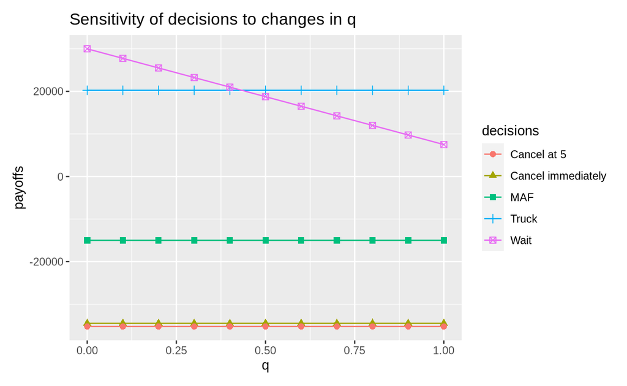

```r
sensitivity(
  result,
  vars = "q 0 1 .1",
  decs = c("Truck", "Cancel immediately", "Wait", "MAF", "Cancel at 5"),
  custom = FALSE
)
```

```r
plot(result, final = TRUE) %>% render()
```

[interactive chart not shown]

## Question 2

EXERCISE 1.2 The Newtowne Art Gallery has a valuable painting that it wishes to sell at auction. There will be three bidders for the painting. The first bidder will bid on Monday, the second will bid on Tuesday, and the third will bid on Wednesday. Each bid must be accepted or rejected that same day. If all three bids are rejected, the painting will be sold for a standing offer of $900,000. Newtowne’s chief auctioneer’s estimates for the bid probabilities are contained in Table 1.5. For example, the auctioneer has estimated that the likelihood the second bidder will bid $2,000,000 is p = 0.90

### Part A / Part B

1. Formulate the problem of deciding which bid to accept as a decision tree.
2. Solve for the optimal decision strategy.

```r
result <- dtree(yl = "DMD_Ex1_2")
summary(result, input = TRUE, output = FALSE)
```

```
Decision tree input:
name: Newtowne Art
type: chance
Monday 2M:
    p: 0.5
    type: decision
    Accept M:
        payoff: 2000000
    Reject M:
        type: chance
        Tuesday 2m:
            p: 0.9
            type: decision
            Accept T:
                payoff: 2000000
            Reject T:
                type: chance
                Wednesday 1m:
                    p: 0.7
                    type: decision
                    Accept W:
                        payoff: 1000000
                    Reject W:
                        payoff: 900000
                Wednesday 4m:
                    p: 0.3
                    type: decision
                    Accept W:
                        payoff: 4000000
                    Reject W:
                        payoff: 900000
        Tuesday 4m:
            p: 0.1
            type: decision
            Accept T:
                payoff: 4000000
            Reject T:
                type: chance
                Wednesday 1m:
                    p: 0.7
```

[output cut: 46 more lines]

```
                type: chance
                Wednesday 1m:
                    p: 0.7
                    type: decision
                    Accept W:
                        payoff: 1000000
                    Reject W:
                        payoff: 900000
                Wednesday 4m:
                    p: 0.3
                    type: decision
                    Accept W:
                        payoff: 4000000
                    Reject W:
                        payoff: 900000
```

```r
plot(result, final = TRUE) %>% render()
```

[interactive chart not shown]